# Analysis File

**Brain Volume Loss in Alzheimer’s Disease: The Roles of Age and Gender in the Relationship Between Atrophy and Cognitive Decline**

This Quarto notebook is the computational companion to the manuscript.  
Everything needed to reproduce my results (raw data, code, statistics, and figures) is executed here in a single linear workflow.

**What you’ll find inside**

| Section | What it does |
| --- | --- |
| **1 Data loading & cleaning & Helper functions** | Reads the anonymised dataset from `/data`, converts raw variables into analysis-ready factors, and builds a summary dataframe for the descriptive table. Also includes re-usable utilities for p-value f… |
| **2 Analyses** | Runs assumption checks, baseline group comparisons, correlations, ANOVAs, and produces all APA-style tables and figures. |

Happy replicating! 🙂

# 1. Data Loading

## 1.1 Helper Functions

In the cell below I report which packages I am using, and which helper functions I have defined.

```r
# -------------------------------------------------------------------------
#  PURPOSE: Load R packages and define helper utilities used
#           throughout the analysis.
# -------------------------------------------------------------------------

# Core data wrangling / plotting
library(tidyverse) # ggplot2, dplyr, tidyr, etc.
library(here)  # avoid fragile absolute paths
library(broom)      # converts test objects to data frames
library(tibble)
library(janitor)
library(patchwork)   # layout multiple ggplots

# APA helpers (tables, theme_apa)
library(papaja) # apa_table(), theme_apa()

# Lightweight stats helpers
library(rstatix)   # p_format, p_round
library(effsize)   # cohen.d()
library(car)       # leveneTest()
library(cocor)     # comparing correlations
library(effectsize)   # eta_squared()

# Reporting niceties
library(glue) # inline string templating
library(kableExtra) # nicely formatted tables (if not using papaja)

# -------------------------------------------------------------------------
# Helper operators / functions
# -------------------------------------------------------------------------
`%+%` <- function(a, b) paste0(a, b)  # quick string concat

nbsp   <- "\u00A0"                    # non-breaking space for aligned APA tables
indent <- function(level = 1) strrep(nbsp, 3 * level)

# APA-style p-value formatter used repeatedly later
apa_p <- function(p) {
  p %>%
    p_round(digits = 3) %>%
    p_format(accuracy = .001,
             leading.zero  = FALSE,
             trailing.zero = FALSE,
             add.p         = FALSE,
             space         = TRUE)
}
# helper to build one APA table
make_anova_tbl <- function(model, caption) {
  # -------- tidy F, df, p from papaja -----------------
  tbl <- papaja::apa_print(model)$table |>
    dplyr::rename(term = term)          # make sure column exists

  # -------- partial η² + CI from effectsize ----------
  eta <- effectsize::eta_squared(
            model, partial = TRUE, ci = 0.95,
            include_intercept = FALSE
         ) |>
    dplyr::rename(term   = Parameter,
                  eta2   = Eta2_partial) |>
    dplyr::mutate(term = janitor::make_clean_names(term))

  # -------- harmonise term labels in tbl -------------
  tbl <- tbl |>
    dplyr::mutate(term = janitor::make_clean_names(term))

  # -------- merge & prettify -------------------------
  tbl <- dplyr::left_join(tbl, eta, by = "term") |>
    dplyr::mutate(
      `η²_p [95% CI]` =
        dplyr::case_when(
          !is.na(eta2) ~ glue::glue("{round(eta2, 2)} [{round(CI_low, 2)}, {round(CI_high, 2)}]"),
          TRUE         ~ "—"
        )
    ) |>
    dplyr::select(term, df, statistic, p.value, `η²_p [95% CI]`) |>
    dplyr::mutate(
      term = stringr::str_replace_all(term, "_", " ") |>   # prettier row labels
             stringr::str_replace_all("x", "×")            # restore × symbol
    )
tbl$term <- stringr::str_replace_all(tbl$term, "times", "×")

  papaja::apa_table(
    tbl,
    caption = caption,
    escape  = FALSE
  )
}
# Helper plotting function to plot interaction
plot_interaction <- function(df, xvar, xlabel, title) {
  ggplot(df,
         aes(x = {{ xvar }}, y = M, fill = Dementia_groups)) +
    geom_col(
      position = position_dodge(.6), width = .55, colour = "black"
    ) +
    geom_errorbar(
      aes(ymin = CI_low, ymax = CI_high),
      width = .1, position = position_dodge(.6)
    ) +
    scale_fill_manual(values = c("white", "grey65")) +
    labs(x = xlabel, y = "Mean nWBV", title = title, fill = "Group") +
    scale_y_continuous(expand = expansion(mult = c(0, .05))) +
    papaja::theme_apa(base_size = 11) +
    theme(
      panel.grid.major.x = element_blank()
    )
}
```

## 1.2 Data Loading

Here I load the raw CSV from the `data/` folder using **here** so the path works on every machine. No transformations yet.

```r
# -------------------------------------------------------------------------
#  PURPOSE: Import the anonymised dataset.
# -------------------------------------------------------------------------


df <- read_csv(
  here("data", "data.csv"),
  show_col_types = FALSE               # suppress verbose readr message
)
```

## 1.3 Recoding

Here I am recoding the variable CDR that has three factors into CDR_binary that merges CDR Status 0.5 and 1 into a shared factor.

```r
# -------------------------------------------------------------------------
#  PURPOSE: Recode factor variables and binary labels used throughout.
#           This is the cleaned version used in all later analysis.
# -------------------------------------------------------------------------

df <- df %>%
  mutate(
    Gender     = factor(Gender, labels = c("Male", "Female")),
    CDR_binary = if_else(CDR == 0, "CDR 0", "CDR 0.5 or 1")
  )
```

## 1.4 Summary Dataframe for Descriptive Statistics Table

Here I build a summary dataframe to later base my sample characteristics table on. This is done in a wide-format to make the APA formatting by papaja easier.

```r
# -------------------------------------------------------------------------
#  PURPOSE: Build wide-format summary df for APA-style reporting
#           of group characteristics by dementia status.
# -------------------------------------------------------------------------

summary_df <- df %>%
  group_by(CDR_binary) %>%
  summarise(
    n        = n(),
    Female   = sum(Gender == "Female"),
    Male     = sum(Gender == "Male"),
    Age      = sprintf("%.2f (%.2f)",  mean(Age,  na.rm = TRUE), sd(Age,  na.rm = TRUE)),
    Education= sprintf("%.2f (%.2f)",  mean(EDUC, na.rm = TRUE), sd(EDUC, na.rm = TRUE)),
    MMSE     = sprintf("%.2f (%.2f)",  mean(MMSE, na.rm = TRUE), sd(MMSE,   na.rm = TRUE)),
    VeryMild = sum(CDR == 0.5),
    Mild     = sum(CDR == 1),
    .groups  = "drop"
  ) %>%
  mutate(
    Female   = glue("{Female} ({round(Female / n * 100, 1)}%)"),
    Male     = glue("{Male} ({round(Male   / n * 100, 1)}%)"),
    VeryMild = glue("{VeryMild} ({round(VeryMild / n * 100, 1)}%)"),
    Mild     = glue("{Mild} ({round(Mild   / n * 100, 1)}%)")
  ) %>%
  mutate(across(-CDR_binary, as.character))   # ←‑ make everything character first

# ---- reshape wide <‑> long ---------------------------------------------------
long <- summary_df %>%
  pivot_longer(-CDR_binary, names_to = "Variable", values_to = "Value")

wide <- long %>%
  pivot_wider(names_from = CDR_binary, values_from = Value)
```

# 2. Analyses

## 2.1 Descriptive Statistics Table (APA-formatted)

Now I assemble the sample descriptive statistics table and format it to match the APA 7 guidelines. The formatting part almost made me cry, so I had to revert to chatGPT.

```r
# -------------------------------------------------------------------------
#  PURPOSE: Build an APA-style table reporting the sample characteristics
#           split by dementia groups.
# -------------------------------------------------------------------------
tbl <- bind_rows(
  tibble(Variable = "Gender, *N* (*%*)",                 `CDR 0` = "", `CDR 0.5 or 1` = ""),
  tibble(Variable = indent(1) %+% "Female",              wide %>% filter(Variable == "Female")    %>% select(-Variable)),
  tibble(Variable = indent(1) %+% "Male",                wide %>% filter(Variable == "Male")      %>% select(-Variable)),
  tibble(Variable = "Age (years), *M* (*SD*)",           wide %>% filter(Variable == "Age")       %>% select(-Variable)),
  tibble(Variable = "Years of education, *M* (*SD*)",    wide %>% filter(Variable == "Education") %>% select(-Variable)),
  tibble(Variable = "MMSE, *M* (*SD*)",                  wide %>% filter(Variable == "MMSE")      %>% select(-Variable)),
  tibble(Variable = "CDR stage, *N* (*%*)",              `CDR 0` = "", `CDR 0.5 or 1` = ""),
  tibble(Variable = indent(1) %+% "Very mild",           wide %>% filter(Variable == "VeryMild")  %>% select(-Variable)),
  tibble(Variable = indent(1) %+% "Mild",                wide %>% filter(Variable == "Mild")      %>% select(-Variable))
)

tbl <- tbl %>%
  mutate(across(-Variable, ~ str_replace_all(.x, "%", "<em>%</em>"))) # italicise the % sign

Ns <- df %>% count(CDR_binary) %>% deframe()                          #two-line column header
colnames(tbl) <- c(
  "",
  glue("CDR 0<br><em>n</em> = {Ns['CDR 0']}"),
  glue("CDR 0.5 or 1<br><em>n</em> = {Ns['CDR 0.5 or 1']}")
)

apa_table(
  tbl,
  align   = "l",
  escape  = FALSE,
  caption = "Descriptive statistics"
)
```

(#tab:unnamed-chunk-5) Descriptive statistics

|  | CDR 0 *n* = 66 | CDR 0.5 or 1 *n* = 73 |
| --- | --- | --- |
| Gender, *N* (*%*) |  |  |
| Female | 45 (68.2*%*) | 30 (41.1*%*) |
| Male | 21 (31.8*%*) | 43 (58.9*%*) |
| Age (years), *M* (*SD*) | 73.41 (8.75) | 73.38 (7.04) |
| Years of education, *M* (*SD*) | 15.55 (2.44) | 13.79 (2.89) |
| MMSE, *M* (*SD*) | 29.27 (0.85) | 25.36 (3.60) |
| CDR stage, *N* (*%*) |  |  |
| Very mild | 0 (0*%*) | 56 (76.7*%*) |
| Mild | 0 (0*%*) | 17 (23.3*%*) |

## 2.2. Assumption Checks

Before running inferential tests, I verify key assumptions (expected counts, homogeneity of variance, normality) and summarize them in a single table.

```r
# -------------------------------------------------------------------------
#  PURPOSE: Conduct assumption checks and report them in a table
# -------------------------------------------------------------------------


## χ² expected counts
contingency_table <- table(df$Gender, df$CDR_binary)
chi_sq            <- chisq.test(contingency_table)
exp_min           <- min(chi_sq$expected)     # smallest expected cell

## Levene’s tests
lev_age  <- leveneTest(Age  ~ CDR_binary, df)
lev_edu  <- leveneTest(EDUC ~ CDR_binary, df)
lev_mmse <- leveneTest(MMSE ~ CDR_binary, df)

## Shapiro–Wilk tests
shap_age  <- shapiro.test(df$Age)
shap_edu  <- shapiro.test(df$EDUC)
shap_mmse <- shapiro.test(df$MMSE)

# Build Assumption Table

assumptions_tbl <- bind_rows(
  tibble(
    Variable  = "Gender χ²",
    Check     = "Min expected",
    Statistic = round(exp_min, 2),
    df        = NA,
    p         = NA_character_
  ),
  tibble(
    Variable  = c("Age", "Education", "MMSE"),
    Check     = "Levene F",
    Statistic = round(c(
      lev_age$`F value`[1],
      lev_edu$`F value`[1],
      lev_mmse$`F value`[1]), 2),
    df        = c(
      glue("{lev_age$Df[1]}, {lev_age$Df[2]}"),
      glue("{lev_edu$Df[1]}, {lev_edu$Df[2]}"),
      glue("{lev_mmse$Df[1]}, {lev_mmse$Df[2]}")),
    p         = c(
      apa_p(lev_age$`Pr(>F)`[1]),
      apa_p(lev_edu$`Pr(>F)`[1]),
      apa_p(lev_mmse$`Pr(>F)`[1]))
  ),
  tibble(
    Variable  = c("Age", "Education", "MMSE"),
    Check     = "Shapiro W",
    Statistic = round(c(
      shap_age$statistic,
      shap_edu$statistic,
      shap_mmse$statistic), 2),
    df        = NA,
    p         = c(
      apa_p(shap_age$p.value),
      apa_p(shap_edu$p.value),
      apa_p(shap_mmse$p.value))
  )
)

apa_table(
  assumptions_tbl,
  caption = "Assumption checks",
  escape  = FALSE
)
```

(#tab:unnamed-chunk-6) Assumption checks

| Variable | Check | Statistic | df | p |
| --- | --- | --- | --- | --- |
| Gender χ² | Min expected | 30.39 | NA | NA |
| Age | Levene F | 2.43 | 1, 137 | .12 |
| Education | Levene F | 1.59 | 1, 137 | .21 |
| MMSE | Levene F | 78.19 | 1, 137 | < .001 |
| Age | Shapiro W | 0.96 | NA | < .001 |
| Education | Shapiro W | 0.94 | NA | < .001 |
| MMSE | Shapiro W | 0.80 | NA | < .001 |

The distribution of MMSE scores showed a strong deviation from normality (*W* = 0.8, *p* < .001) and from equal-variances *F(*1, 137) =78.19, *p* < .001. Therefore, the group comparison was conducted using Welch’s *t*-test, which does not assume equal variances or normality.

## 2.3. Baseline Differences

Here we compare the two groups on gender, age, education, and MMSE, reporting effect sizes alongside χ² and *t*/Welch tests.

```r
# -------------------------------------------------------------------------
#  PURPOSE: Compute baseline differences and effect size, and report in
#           APA table.
# -------------------------------------------------------------------------

# χ² (already computed above as chi_sq)

# t / Welch tests and effect sizes
t_age   <- t.test(Age  ~ CDR_binary, df, var.equal = TRUE)
d_age   <- cohen.d(df$Age,  df$CDR_binary)

t_edu   <- t.test(EDUC ~ CDR_binary, df, var.equal = TRUE)
d_edu   <- cohen.d(df$EDUC, df$CDR_binary)

t_mmse  <- t.test(MMSE ~ CDR_binary, df, var.equal = FALSE)   # Welch
d_mmse  <- cohen.d(df$MMSE, df$CDR_binary)

# Build  table

baseline_tbl <- bind_rows(
  tidy(chi_sq) %>%
    transmute(Variable = "Gender", Test = "χ²",
              `df` = parameter,
              Statistic = round(statistic, 2),
              `p` = apa_p(p.value),
              `Cohen's d` = NA),
  tidy(t_age) %>%
    transmute(Variable = "Age", Test = "t",
              `df` = parameter,
              Statistic = round(statistic, 2),
              `p` = apa_p(p.value),
              `Cohen's d` = apa_p(d_age$estimate)),
  tidy(t_edu) %>%
    transmute(Variable = "Education", Test = "t",
              `df` = parameter,
              Statistic = round(statistic, 2),
              `p` = apa_p(p.value),
              `Cohen's d` = apa_p(d_edu$estimate)),
  tidy(t_mmse) %>%
    transmute(Variable = "MMSE", Test = "Welch t",
              `df` = parameter,
              Statistic = round(statistic, 2),
              `p` = apa_p(p.value),
              `Cohen's d` = apa_p(d_mmse$estimate))
)

apa_table(
  baseline_tbl,
  caption = "Baseline comparisons between dementia and non-dementia groups",
  escape  = FALSE
)
```

(#tab:unnamed-chunk-7) Baseline comparisons between dementia and non-dementia groups

| Variable | Test | df | Statistic | p | Cohen’s d |
| --- | --- | --- | --- | --- | --- |
| Gender | χ² | 1.00 | 9.17 | .002 | NA |
| Age | t | 137.00 | 0.02 | .98 | .003 |
| Education | t | 137.00 | 3.84 | < .001 | .65 |
| MMSE | Welch t | 80.82 | 9.01 | < .001 | 1.5 |

## 2.4. Correlation

Here I examine the nWBV–MMSE relationship overall and by group, then use a Fisher *r*-to-*z* test to see whether the subgroup correlations differ.

```r
# -------------------------------------------------------------------------
#  PURPOSE: Compute correlations between nWBV and MMSE scores, and check
#           if they differ significantly by dementia status.
# -------------------------------------------------------------------------

# Compute Correlations
## Overall Correlation
cor_all <- cor.test(df$nWBV, df$MMSE, method = "pearson")

## Correlation by Groups
r_nondementia <- cor.test(
  subset(df, Dementia_groups == 0)$nWBV,
  subset(df, Dementia_groups == 0)$MMSE,
  method = "pearson" )

r_dementia <- cor.test(
  subset(df, Dementia_groups == 1)$nWBV,
  subset(df, Dementia_groups == 1)$MMSE,
  method = "pearson" )

#Fisher r‑to‑z comparison

fish <- cocor.indep.groups(
  r1 = r_dementia$estimate,
  r2 = r_nondementia$estimate,
  n1 = nrow(subset(df, Dementia_groups == 1)),
  n2 = nrow(subset(df, Dementia_groups == 0)),
  alternative = "two.sided",
  conf.level = 0.95 )

# Build Correlation Table
corr_tbl <- tibble(
  Group      = c("Overall", "No dementia", "Dementia"),
  Statistic  = c(
    round(cor_all$estimate, 2),
    round(r_nondementia$estimate, 2),
    round(r_dementia$estimate, 2)
  ),
  p = c(
    apa_p(cor_all$p.value),
    apa_p(r_nondementia$p.value),
    apa_p(r_dementia$p.value)
  )
)

apa_table(
  corr_tbl,
  caption = "Correlations between nWBV and MMSE",
  escape  = FALSE
)
```

(#tab:unnamed-chunk-8) Correlations between nWBV and MMSE

| Group | Statistic | p |
| --- | --- | --- |
| Overall | 0.37 | < .001 |
| No dementia | 0.03 | .81 |
| Dementia | 0.36 | .002 |

Additionally I checked whether the two correlations are significantly different from each other using a Fisher r-to-z comparison ($z=$ 1.98, $p=$ .048).

## 2.5 Correlation Figure

The scatter-plot below visualises the two correlation lines with distinct point markers for each dementia status.

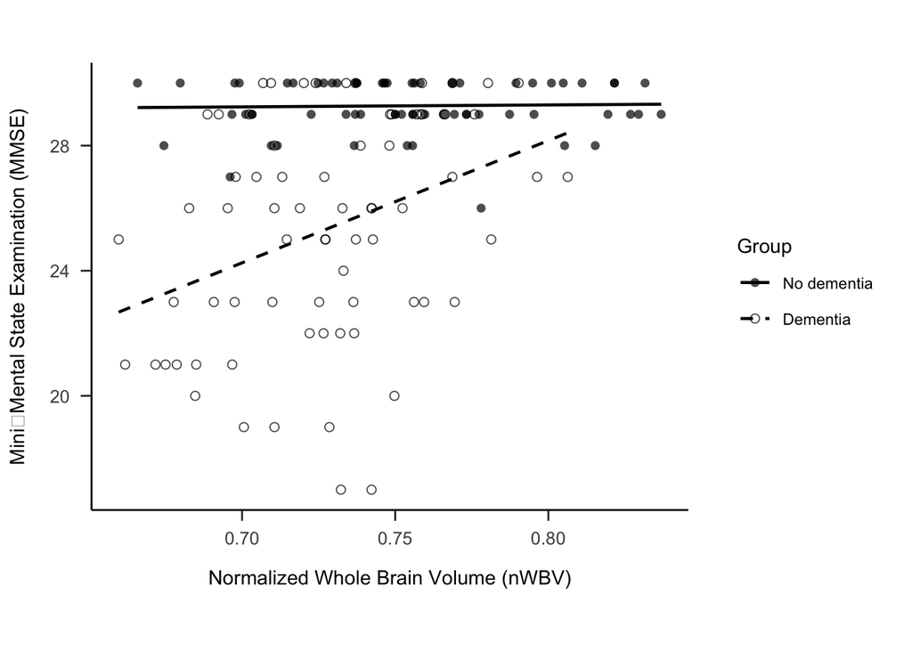

```r
# -------------------------------------------------------------------------
#  PURPOSE: Visualize the Correlations in an APA-style scatter plot.
# -------------------------------------------------------------------------


# Label the grouping variable nicely
df$Dementia_groups <- factor(
  df$Dementia_groups,
  levels = c(0, 1),
  labels = c("No dementia", "Dementia")
)

# Building the Scatter Plot

ggplot(df, aes(nWBV, MMSE)) +
  geom_point(
    aes(shape = Dementia_groups),
    colour = "black", size = 2, alpha = .70
  ) +
  geom_smooth(
    aes(linetype = Dementia_groups),
    method   = "lm",
    se       = FALSE,
    colour   = "black",
    linewidth = .8
  ) +
  scale_shape_manual(values = c(16, 1)) +         # filled vs open circles
  scale_linetype_manual(values = c("solid", "dashed")) +
  labs(
    x        = "Normalized Whole Brain Volume (nWBV)",
    y        = "Mini‑Mental State Examination (MMSE)",
    shape    = "Group",
    linetype = "Group"
  ) +
theme_apa(base_size = 11) +              # APA 7 look‑and‑feel
  theme(legend.position = "right",
        aspect.ratio   = 3/4)
```

## 2.6. Inferential Statistics

### 2.6.1. Fit Models

Next we fit two separate 2 × 2 between-subjects ANOVAs: Dementia × Age and Dementia × Gender.

```r
# -------------------------------------------------------------------------
#  PURPOSE: Fit 2×2 ANOVAs (Dementia × Age  and  Dementia × Gender)
# -------------------------------------------------------------------------
model_DxA <- aov(nWBV ~ Dementia_groups * Age_groups,    data = df)
model_DxG <- aov(nWBV ~ Dementia_groups * Gender,        data = df)
```

### 2.6.2. Build ANOVA tables

The helper function `make_anova_tbl()` converts each model into an APA-style table with partial η² and CIs.

```r
make_anova_tbl(model_DxA,
  "ANOVA: Dementia status × Age group on nWBV")
```

(#tab:unnamed-chunk-11) ANOVA: Dementia status × Age group on nWBV

| term | $\mathit{df}$ | $F$ | $p$ | η²_p [95% CI] |
| --- | --- | --- | --- | --- |
| dementia groups | 1 | 23.22 | < .001 | 0.15 [0.07, 1] |
| age groups | 1 | 47.52 | < .001 | 0.26 [0.16, 1] |
| dementia groups × age groups | 1 | 5.40 | .022 | — |

```r
make_anova_tbl(model_DxG,
  "ANOVA: Dementia status × Gender on nWBV")
```

(#tab:unnamed-chunk-11) ANOVA: Dementia status × Gender on nWBV

| term | $\mathit{df}$ | $F$ | $p$ | η²_p [95% CI] |
| --- | --- | --- | --- | --- |
| dementia groups | 1 | 17.38 | < .001 | 0.11 [0.04, 1] |
| gender | 1 | 4.18 | .043 | 0.03 [0, 1] |
| dementia groups × gender | 1 | 1.51 | .221 | — |

### 2.6.3. Cell means, marginal means, SDs

This chunk calculates group means, SDs, and 95 % CIs that feed both the write-up and the interaction plots.

```r
# -------------------------------------------------------------------------
#  PURPOSE: Means & SDs per cell and marginal means for plotting
#           and in-line write-up
# -------------------------------------------------------------------------

cell_stats <- df %>%
  mutate(
    Age_groups      = factor(Age_groups, levels = c(0, 1), labels = c("60–70", "70+")),
    Dementia_groups = factor(Dementia_groups, levels = c("No dementia", "Dementia"))
  ) %>%
  group_by(Dementia_groups, Age_groups) %>%
  summarise(
    n   = n(),
    M   = round(mean(nWBV, na.rm = TRUE),3),
    SD  = round(sd(nWBV,   na.rm = TRUE),3),
    se  = round(SD / sqrt(n),3),
    t95 = round(qt(.975, df = n - 1),3),
    CI_low  = round(M - t95 * se,3),
    CI_high = round(M + t95 * se,3),
    .groups = "drop"
  )

marg_by_dementia <- cell_stats %>%
  group_by(Dementia_groups) %>%
  summarise(
    M  = mean(M),
    SD = sqrt(mean(SD^2)),
    .groups = "drop"
  )

marg_by_age <- cell_stats %>%
  group_by(Age_groups) %>%
  summarise(
    M  = mean(M),
    SD = sqrt(mean(SD^2)),
    .groups = "drop"
  )

# Assemble quick table for inspection
knitr::kable(cell_stats, caption = "Cell means and SDs for nWBV")
```

Cell means and SDs for nWBV

| Dementia_groups | Age_groups | n | M | SD | se | t95 | CI_low | CI_high |
| --- | --- | --- | --- | --- | --- | --- | --- | --- |
| No dementia | 60–70 | 31 | 0.781 | 0.037 | 0.007 | 2.042 | 0.767 | 0.795 |
| No dementia | 70+ | 35 | 0.731 | 0.030 | 0.005 | 2.032 | 0.721 | 0.741 |
| Dementia | 60–70 | 32 | 0.743 | 0.032 | 0.006 | 2.040 | 0.731 | 0.755 |
| Dementia | 70+ | 41 | 0.717 | 0.030 | 0.005 | 2.021 | 0.707 | 0.727 |

### 2.6.4. Interaction Plot

Finally, we visualise the Dementia × Age and Dementia × Gender interactions side-by-side with bars and 95 % CI error bars.

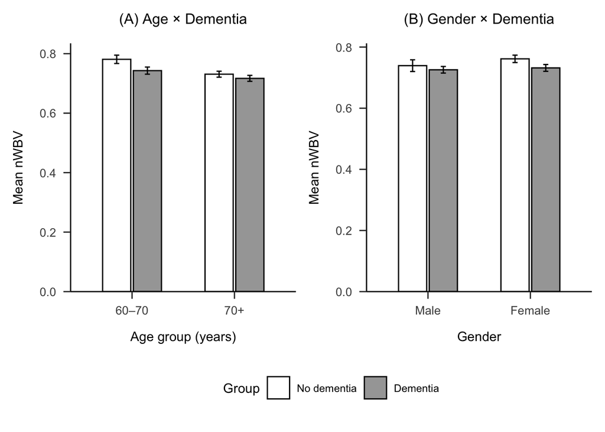

```r
# -------------------------------------------------------------------------
#  PURPOSE: Two side-by-side barplots of mean nWBV with 95 % CIs:
#           (A) Dementia × Age-group   (B) Dementia × Gender
#           → Uses cell means/SDs computed earlier in `cell_stats`
# -------------------------------------------------------------------------

# Prepare a summary for the Gender panel
gender_ci <- df %>%
  mutate(
    Dementia_groups = factor(Dementia_groups,
                             levels = c("No dementia", "Dementia")),
    Gender = factor(Gender, levels = c("Male", "Female"))
  ) %>%
  group_by(Dementia_groups, Gender) %>%
  summarise(
    n       = n(),
    M       = mean(nWBV, na.rm = TRUE),
    SD      = sd(nWBV,   na.rm = TRUE),
    se      = SD / sqrt(n),
    t95     = qt(.975, df = n - 1),
    CI_low  = M - t95 * se,
    CI_high = M + t95 * se,
    .groups = "drop"
  )

# Prepare a summary for the Age panel
age_ci <- cell_stats


# Build each panel individually
# -------------------------------------------------------------------------
p_age    <- plot_interaction(age_ci,    Age_groups, "Age group (years)", "(A) Age × Dementia")
p_gender <- plot_interaction(gender_ci, Gender,     "Gender",            "(B) Gender × Dementia")


#Arrange side-by-side with a shared legend at the bottom
(p_age | p_gender) +
  plot_layout(guides = "collect") &
  theme(legend.position = "bottom")
```